# rel

rel_author

2025-11-08

### Relatório 2 - Comparando Nações (PIB per capita)

#### Pergunta-Chave

Como o PIB per capita do Brasil se compara ao de seus vizinhos sul-americanos (Argentina, Chile, Colômbia) e ao dos EUA nas últimas duas décadas?

#### Descrição dos Dados

Usaremos o pacote *WDI* para acessar a base de dados World Development Indicators (WDI) do Banco Mundial. Buscaremos o indicador “NY.GDP.PCAP.CD”, que é o PIB per capita em dólares americanos correntes.

Vamos mostrar os códigos e os resultados. Para esconder os códigos do resultado, colocar *echo = FALSE*. Observar primeiro bloco de código abaixo com essa propriedade inserida.

Bloco de código 1. Carregamento de pacotes (omitido)

Bloco de código 2. Carregamento de dados

```r
# 2. Carga de dados - arquivo no Temp

#### ajustar caminho da pasta - EXEMPLO: '/cloud/project/'

dados_brutos_pib <- readxl::read_excel('C:/mark/projetos/oficina_r_mackrio/dados_pib_banco_mundial.xlsx',
                                        col_types = "text")


# 2.1. - Carga de Dados via pacote do R: Buscando no Banco Mundial
# Definir quais países e qual indicador queremos
# paises_selecionados <- c("BRA", "ARG", "CHL", "COL", "USA") # Códigos ISO
# indicador_pib <- "NY.GDP.PCAP.CD" # PIB per capita (USD corrente)
#
# dados_brutos_pib <- WDI(
#   country = paises_selecionados,
#   indicator = indicador_pib,
#   start = 2000,
#   end = 2023,
#   extra = FALSE # Não queremos colunas extras de metadados
# )
# salvar nos arquivos
# write.csv2(dados_brutos_pib,"dados_pib_banco_mundial.xlsx",sep = ";")

# observar dados parciais para identificar dados baixados
dplyr::tibble(head(dados_brutos_pib))
```

```
## # A tibble: 6 × 5
##   country   iso2c iso3c year  NY.GDP.PCAP.CD
##   <chr>     <chr> <chr> <chr> <chr>
## 1 Argentina AR    ARG   2023  14187.4827252965
## 2 Argentina AR    ARG   2022  13935.6811110049
## 3 Argentina AR    ARG   2021  10738.0179223384
## 4 Argentina AR    ARG   2020  8535.59938004389
## 5 Argentina AR    ARG   2019  9955.97478680428
## 6 Argentina AR    ARG   2018  11752.7998922979
```

Bloco de código 3. Limpeza de dados

```r
# 3. Limpeza dos Dados
# O pacote WDI já entrega os dados bem organizados
dados_tratados_pib <- dados_brutos_pib %>%
  # Renomear colunas para facilitar (e traduzir)
  rename(
    pais = country,
    ano = year,
    pib_per_capita = NY.GDP.PCAP.CD
  ) %>%
  # Remover anos/países onde o dado não estava disponível
  filter(!is.na(pib_per_capita)) %>%
  # Garantir que o ano e o pib são tratados como números
  mutate(ano = as.numeric(ano),
         pib_per_capita = as.numeric(pib_per_capita))

# observar dados prontos
dplyr::tibble(head(dados_tratados_pib))
```

```
## # A tibble: 6 × 5
##   pais      iso2c iso3c   ano pib_per_capita
##   <chr>     <chr> <chr> <dbl>          <dbl>
## 1 Argentina AR    ARG    2023         14187.
## 2 Argentina AR    ARG    2022         13936.
## 3 Argentina AR    ARG    2021         10738.
## 4 Argentina AR    ARG    2020          8536.
## 5 Argentina AR    ARG    2019          9956.
## 6 Argentina AR    ARG    2018         11753.
```

Bloco de código 4. Tratamento adicional nos dados

```r
# AJUSTE DE RÓTULOS

# dados_tratados_pib <- dados_tratados_pib %>%
#   mutate(
#     pais_novo = case_when(
#       pais == "Brazil" ~ "Brasil",
#       pais == "United States" ~ "Estados Unidos",
#       .default = pais
#     )
#   )
```

Bloco de código 5. Visualização inicial

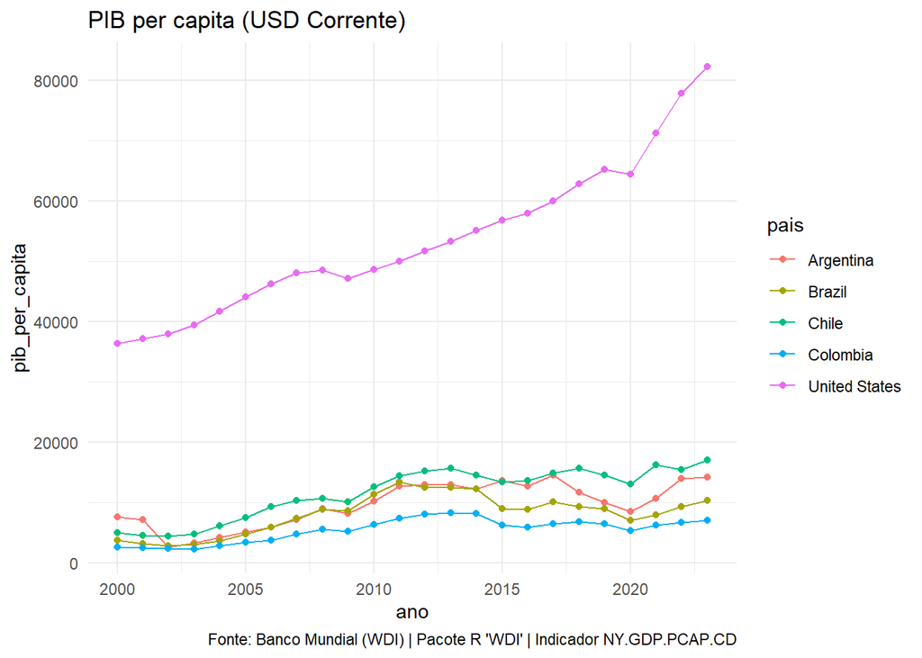

```r
# 5. Visualização dos Resultados

ggplot(dados_tratados_pib, aes(x = ano, y = pib_per_capita, color = pais)) +
  geom_line(aes(group = pais)) +
  geom_point() +

  labs(
    title = "PIB per capita (USD Corrente)",
    caption = "Fonte: Banco Mundial (WDI) | Pacote R 'WDI' | Indicador NY.GDP.PCAP.CD"
  ) +
  theme_minimal()
```

Bloco de código 6. Visualização para análise

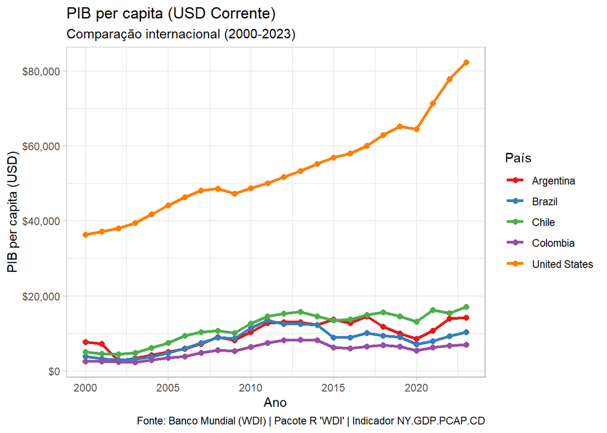

```r
# 5. Visualização dos Resultados
ggplot(dados_tratados_pib, aes(x = ano, y = pib_per_capita, color = pais)) +
  # Usar 'group = pais' garante que o R desenhe uma linha para cada país
  geom_line(aes(group = pais), linewidth = 1.2) +
  geom_point(size = 2) + # Adiciona pontos em cada ano

  # Formatar o eixo Y para mostrar como dólar
  scale_y_continuous(labels = scales::dollar_format()) +
  scale_color_brewer(palette = "Set1") +

  labs(
    title = "PIB per capita (USD Corrente)",
    subtitle = "Comparação internacional (2000-2023)",
    y = "PIB per capita (USD)",
    x = "Ano",
    color = "País", # Legenda
    caption = "Fonte: Banco Mundial (WDI) | Pacote R 'WDI' | Indicador NY.GDP.PCAP.CD"
  ) +
  theme_light() # Um tema um pouco diferente
```